# Class 11: Restricted Mean Survival Time Analysis

# 4. Time interaction term.

```r
#Add an interaction term between the survival time variable of interest and the exposure variable but this is not straightforward in R like it is in other programs (see discussion here: http://sas-and-r.blogspot.com/2010/06/example-742-testing-proportionality.html)

#code from: https://rpubs.com/kaz_yos/kleinbaum-ph-assumption

## Split a survival data set at specified times to form a counting process format
leuk$id <- as.numeric(rownames(leuk))
leuk.cp.format <- survSplit(data  = leuk,
                            cut   = c(7),       # cut at time 7
                            end   = "survt",    # original survival time
                            event = "status",   # event indicator
                            start = "start")    # will be created. zero by default

## Recoding
leuk.cp.format <- within(leuk.cp.format, {

    ## Create new survival object
    SurvObj <- Surv(start, survt, status)

    ## Create interval indicator
    interval <- factor(start, levels = c(0,7), labels = c("First","Second"))
})

## Reordering
leuk.cp.format <- leuk.cp.format[with(leuk.cp.format, order(id, survt)),]

## Fit extended Cox model with multiple interaction terms
## cluster(id) for robutst SE to account for within-cluster non-independence
res.extended.coxa <- coxph(SurvObj ~ rx + logwbc + sex + rx*interval + logwbc*interval + sex*interval + cluster(id), data = leuk.cp.format)
summary(res.extended.coxa)
```

```
## Call:
## coxph(formula = SurvObj ~ rx + logwbc + sex + interval + rx:interval +
##     logwbc:interval + sex:interval, data = leuk.cp.format, cluster = id)
##
##   n= 70, number of events= 30
##
##                          coef exp(coef) se(coef) robust se      z Pr(>|z|)
## rx                     1.0079    2.7400   0.6567    0.5170  1.950 0.051209 .
## logwbc                 1.6744    5.3355   0.4433    0.4984  3.360 0.000781 ***
## sex                    1.2535    3.5026   0.6523    0.5093  2.461 0.013838 *
## intervalSecond             NA        NA   0.0000    0.0000     NA       NA
## rx:intervalSecond      0.2972    1.3461   0.9542    0.8925  0.333 0.739148
## logwbc:intervalSecond -0.2863    0.7511   0.7118    0.6987 -0.410 0.682026
## sex:intervalSecond    -2.0064    0.1345   1.0476    1.0478 -1.915 0.055505 .
## ---
## Signif. codes:  0 '***' 0.001 '**' 0.01 '*' 0.05 '.' 0.1 ' ' 1
##
##                       exp(coef) exp(-coef) lower .95 upper .95
## rx                       2.7400     0.3650   0.99472     7.547
## logwbc                   5.3355     0.1874   2.00882    14.171
## sex                      3.5026     0.2855   1.29094     9.503
## intervalSecond               NA         NA        NA        NA
## rx:intervalSecond        1.3461     0.7429   0.23408     7.740
## logwbc:intervalSecond    0.7511     1.3315   0.19094     2.954
## sex:intervalSecond       0.1345     7.4362   0.01725     1.048
##
## Concordance= 0.867  (se = 0.039 )
## Likelihood ratio test= 52.44  on 6 df,   p=2e-09
## Wald test            = 58.88  on 6 df,   p=8e-11
## Score (logrank) test = 58.08  on 6 df,   p=1e-10,   Robust = 29.9  p=4e-05
##
##   (Note: the likelihood ratio and score tests assume independence of
##      observations within a cluster, the Wald and robust score tests do not).
```

```r
## Testing the rx variable only
## cluster(id) for robutst SE to account for within-cluster non-independence
res.extended.cox <- coxph(SurvObj ~ rx + rx*interval + cluster(id),
                          data = leuk.cp.format)
summary(res.extended.cox)
```

```
## Call:
## coxph(formula = SurvObj ~ rx + interval + rx:interval, data = leuk.cp.format,
##     cluster = id)
##
##   n= 70, number of events= 30
##
##                     coef exp(coef) se(coef) robust se     z Pr(>|z|)
## rx                1.1159    3.0524   0.6029    0.5624 1.984   0.0472 *
## intervalSecond        NA        NA   0.0000    0.0000    NA       NA
## rx:intervalSecond 0.7823    2.1866   0.8165    0.7397 1.058   0.2902
## ---
## Signif. codes:  0 '***' 0.001 '**' 0.01 '*' 0.05 '.' 0.1 ' ' 1
##
##                   exp(coef) exp(-coef) lower .95 upper .95
## rx                    3.052     0.3276     1.014     9.191
## intervalSecond           NA         NA        NA        NA
## rx:intervalSecond     2.187     0.4573     0.513     9.320
##
## Concordance= 0.69  (se = 0.041 )
## Likelihood ratio test= 17.25  on 2 df,   p=2e-04
## Wald test            = 18.88  on 2 df,   p=8e-05
## Score (logrank) test = 19.01  on 2 df,   p=7e-05,   Robust = 25.02  p=4e-06
##
##   (Note: the likelihood ratio and score tests assume independence of
##      observations within a cluster, the Wald and robust score tests do not).
```

# Solutions for PH assumption violation

- Estimating HRs by time intervals for main exposure of interest
- Stratified Cox PH regression by covariate not meeting the PH assumption
- Ignore it, interpreted as “weighted average” HR
- Restricted mean survival time (RMST) analysis

# 1. Estimating HRs by intervals for main exposure of interest

```r
# By time interval to get HRs

# need to change censorship and follow-up time 0-7 weeks
leuk$survt7 <- ifelse(leuk$survt > 7, 7, leuk$survt)
leuk$status7 <- ifelse(leuk$survt > 7 & leuk$status == 1, 0, leuk$status)
interval0to7 <- coxph(Surv(survt7, status7) ~ rx, leuk)
summary(interval0to7)
```

```
## Call:
## coxph(formula = Surv(survt7, status7) ~ rx, data = leuk)
##
##   n= 42, number of events= 13
##
##      coef exp(coef) se(coef)     z Pr(>|z|)
## rx 1.1159    3.0524   0.6029 1.851   0.0642 .
## ---
## Signif. codes:  0 '***' 0.001 '**' 0.01 '*' 0.05 '.' 0.1 ' ' 1
##
##    exp(coef) exp(-coef) lower .95 upper .95
## rx     3.052     0.3276    0.9364      9.95
##
## Concordance= 0.658  (se = 0.059 )
## Likelihood ratio test= 3.77  on 1 df,   p=0.05
## Wald test            = 3.43  on 1 df,   p=0.06
## Score (logrank) test = 3.79  on 1 df,   p=0.05
```

```r
# >7 weeks--need to exclude people not at risk
leuk2 <- leuk[which(leuk$survt > 7), ]
intervalgt7 <- coxph(Surv(survt, status) ~ rx, leuk2)
summary(intervalgt7)
```

```
## Call:
## coxph(formula = Surv(survt, status) ~ rx, data = leuk2)
##
##   n= 28, number of events= 17
##
##      coef exp(coef) se(coef)     z Pr(>|z|)
## rx 1.8983    6.6743   0.5506 3.448 0.000565 ***
## ---
## Signif. codes:  0 '***' 0.001 '**' 0.01 '*' 0.05 '.' 0.1 ' ' 1
##
##    exp(coef) exp(-coef) lower .95 upper .95
## rx     6.674     0.1498     2.269     19.64
##
## Concordance= 0.744  (se = 0.05 )
## Likelihood ratio test= 13.48  on 1 df,   p=2e-04
## Wald test            = 11.89  on 1 df,   p=6e-04
## Score (logrank) test = 15.22  on 1 df,   p=1e-04
```

```r
# another way using dataset created above called leuk.cp.format
leuk3 <- leuk.cp.format[which(leuk.cp.format$interval == "First"), ]
# use leuk.cp.format dataset interval 1
res.extended.cox <- coxph(Surv(survt, status) ~ rx, leuk3)
summary(res.extended.cox)
```

```
## Call:
## coxph(formula = Surv(survt, status) ~ rx, data = leuk3)
##
##   n= 42, number of events= 13
##
##      coef exp(coef) se(coef)     z Pr(>|z|)
## rx 1.1159    3.0524   0.6029 1.851   0.0642 .
## ---
## Signif. codes:  0 '***' 0.001 '**' 0.01 '*' 0.05 '.' 0.1 ' ' 1
##
##    exp(coef) exp(-coef) lower .95 upper .95
## rx     3.052     0.3276    0.9364      9.95
##
## Concordance= 0.658  (se = 0.059 )
## Likelihood ratio test= 3.77  on 1 df,   p=0.05
## Wald test            = 3.43  on 1 df,   p=0.06
## Score (logrank) test = 3.79  on 1 df,   p=0.05
```

```r
leuk4 <- leuk.cp.format[which(leuk.cp.format$interval == "Second"), ]
# use leuk.cp.format dataset interval 2
res.extended.cox <- coxph(Surv(survt, status) ~ rx, leuk4)
summary(res.extended.cox)
```

```
## Call:
## coxph(formula = Surv(survt, status) ~ rx, data = leuk4)
##
##   n= 28, number of events= 17
##
##      coef exp(coef) se(coef)     z Pr(>|z|)
## rx 1.8983    6.6743   0.5506 3.448 0.000565 ***
## ---
## Signif. codes:  0 '***' 0.001 '**' 0.01 '*' 0.05 '.' 0.1 ' ' 1
##
##    exp(coef) exp(-coef) lower .95 upper .95
## rx     6.674     0.1498     2.269     19.64
##
## Concordance= 0.744  (se = 0.05 )
## Likelihood ratio test= 13.48  on 1 df,   p=2e-04
## Wald test            = 11.89  on 1 df,   p=6e-04
## Score (logrank) test = 15.22  on 1 df,   p=1e-04
```

# 2. Stratified Cox PH regression by covariate not meeting the PH assumption

```r
# model adjusted for sex and WBC that accounts for violation of ph assumption by
# sex
cox.0sexa <- coxph(Surv(survt, status) ~ rx + logwbc + strata(sex), data = leuk)
summary(cox.0sexa)
```

```
## Call:
## coxph(formula = Surv(survt, status) ~ rx + logwbc + strata(sex),
##     data = leuk)
##
##   n= 42, number of events= 30
##
##          coef exp(coef) se(coef)     z Pr(>|z|)
## rx     0.9981    2.7131   0.4736 2.108   0.0351 *
## logwbc 1.4537    4.2787   0.3441 4.225 2.39e-05 ***
## ---
## Signif. codes:  0 '***' 0.001 '**' 0.01 '*' 0.05 '.' 0.1 ' ' 1
##
##        exp(coef) exp(-coef) lower .95 upper .95
## rx         2.713     0.3686     1.072     6.864
## logwbc     4.279     0.2337     2.180     8.398
##
## Concordance= 0.812  (se = 0.059 )
## Likelihood ratio test= 32.06  on 2 df,   p=1e-07
## Wald test            = 22.75  on 2 df,   p=1e-05
## Score (logrank) test = 30.8  on 2 df,   p=2e-07
```

# Benefits of using restricted mean survival time (RMST) analysis

- Valid under any distribution of the time to event
- Readily interpretable as the gain or loss in ‘life expectancy’ between the start of observation and a particular time horizon
- As powerful as logrank test or HR-based tests

# What is RMST?

- Mean survival time (MST) measures expected life time and can be used to quantify the treatment effect in a time domain
- MST is not satisfactory due to heavy censoring or rare events
- In such case, the idea of RMST came from Irwin (1949)
- RMST is a well-established, yet under-utilized measure that can be interpreted as the average event-free survival time up to a pre-specified, clinically important time point t
- The time point t, is defined by the researcher according to the research goals

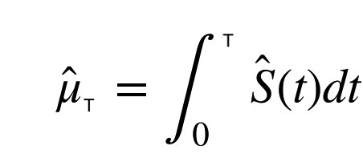

Definition of RMST

- **T** is a random variable indicating a person’s survival time
- **t** any value of **T**
- **S(t)** is used to denote the survivor function. It gives the probability that a person’s survival time exceeds time **t**
- The area under the survival curve S(t) from t=0 to t=1.5

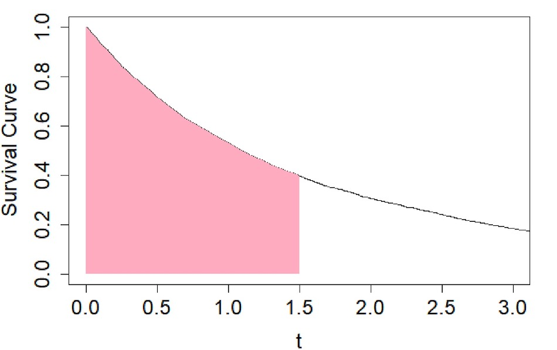

# Restricted mean time lost (RMSL)

- The area “above” the curve of the survival function up to a time t

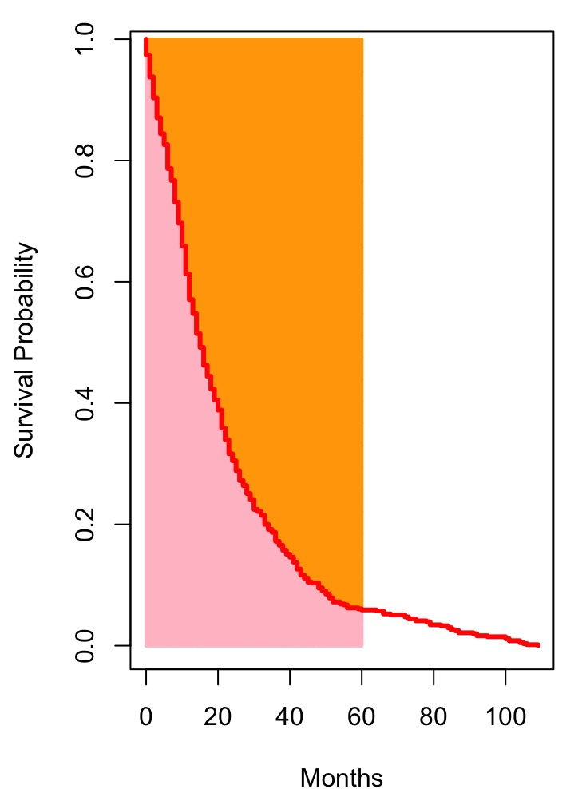

RMSL: Orange area above survival curve; RMST: pink area under the curve

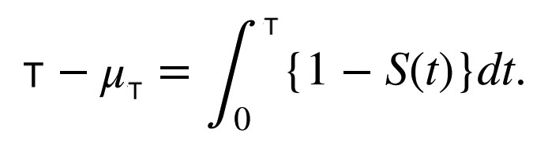

# Difference in RMST: Unadjusted analysis

- RMST difference means gain or loss in the event-free survival time due to treatment vs. control during this period

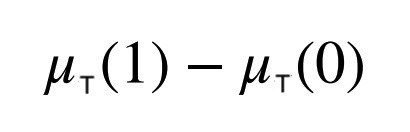

- RMST ratio: ratio of the event-free survival time between treatment vs. control during this period

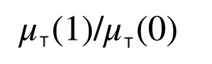

- RMSL ratio: ratio of event-survival time lost between treatment vs. control during this period

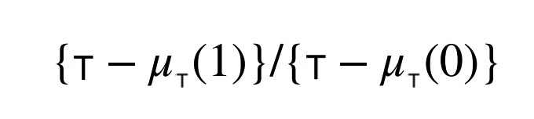

# Execute RMST

- Main function `rmst2(time, status, arm, tau)`
- time: follow-up time
- status: event status
- arm: variable of interest (treatment vs. control)
- tau: specified observation window (smaller than the minimum of the largest observed time in each of the two groups)

```r
# Calculate RMST for both groups using rmst2 function
mod <- rmst2(leuk$survt, leuk$status, leuk$rx, tau = 20)
# Display the model results
print(mod)
```

```
##
## The truncation time: tau = 20  was specified.
##
## Restricted Mean Survival Time (RMST) by arm
##                Est.    se lower .95 upper .95
## RMST (arm=1)  8.429 1.268     5.943    10.914
## RMST (arm=0) 16.117 1.252    13.664    18.570
##
##
## Restricted Mean Time Lost (RMTL) by arm
##                Est.    se lower .95 upper .95
## RMTL (arm=1) 11.571 1.268     9.086    14.057
## RMTL (arm=0)  3.883 1.252     1.430     6.336
##
##
## Between-group contrast
##                        Est. lower .95 upper .95     p
## RMST (arm=1)-(arm=0) -7.688   -11.180    -4.196 0.000
## RMST (arm=1)/(arm=0)  0.523     0.375     0.729 0.000
## RMTL (arm=1)/(arm=0)  2.980     1.529     5.807 0.001
```

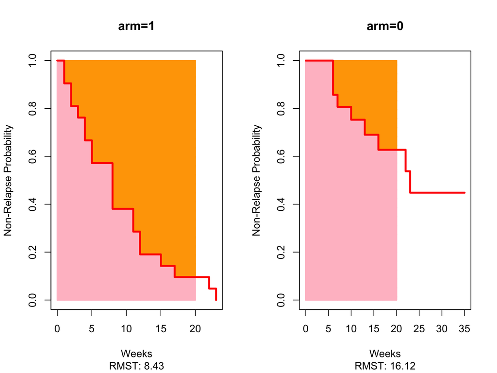

```r
# Plot the survival probability
plot(mod, xlab = "Weeks", ylab = "Non-Relapse Probability")
```

# Interpretation

- **First Block: Restricted Mean Survival Time (RMST) by arm**
- The mean relapse time for individuals treated with placebo was 8.4 weeks when following the patients for 20 weeks
- The mean relapse time for individuals with treatment was 16.1 weeks when following the patients for 20 weeks
- **Second Block: Restricted Mean Time Lost (RMTL) by arm**
- The mean relapse time lost for individuals treated with placebo was 11.6 weeks when following the patients for 20 weeks
- The mean relapse time lost for individuals with treatment was 3.9 weeks when following the patients for 20 weeks
- **Third Block: Between-group contrast**
- The difference in RMST (the first row) was -7.688 weeks, with a 95% confidence interval ranging from -11.180 to -4.196 weeks. The point estimate indicated that the time to relapse since treatment for individuals treated with placebo was 7.688 weeks shorter than individuals with treatment on average, when following the patients for 20 weeks.

# RMST with more than 2 arms (variable of interest with more than two levels)

- Function written
- Key elements in the rmst2_plus function: data, time, status, arm, nlevel, ntime
- data: dataset name
- time: follow-up time
- status: event status
- arm: variable of interest
- nlevel: the number of levels of the variable of interest minus 1
- ntime: tau (specified observation window)

```r
rmst2_plus <- function(data, time, status, arm, nlevel, ntime, ...) {
    # nlevel: the number of levels of variable of interest minus 1
    for (i in 1:nlevel) {
        # level = 1, run the RMST model
        if (i == 1) {
            print("########################################################")
            print(paste0("Below display the model results of arm =", i, " vs. arm = 0."))
            print(data %$% rmst2(time, status, arm, tau = ntime, ...))
        }
        # level > 1, change all levels to MA other than baseline level and the target
        # level
        if (i > 1) {
            print("#########################################################")
            print(paste0("Below display the model results of arm =", i, " vs. arm = 0."))
            print(data %>% mutate(arm = replace(arm, arm < i & arm > 0, NA), arm = replace(arm,
                arm == i, 1)) %>% filter(!is.na(arm)) %$% rmst2(time, status, arm,
                tau = ntime, ...))
        }
    }
}
```

- Use lwbc3 (3 levels) as an example

```r
# Recode lwbc3 to make the reference levels as 0 Create a time variable
leuk <- leuk %>% mutate(lwbc3_ref = lwbc3 - 1, arm = lwbc3_ref, time = survt)

# Check
table(leuk$lwbc3, leuk$arm)
```

```
##
##      0  1  2
##   1 11  0  0
##   2  0 14  0
##   3  0  0 17
```

```r
# RMST model
rmst2_plus(leuk, time, status, arm, 2, 15)
```

```
## [1] "########################################################"
## [1] "Below display the model results of arm =1 vs. arm = 0."
##
## The truncation time: tau = 15  was specified.
##
## Restricted Mean Survival Time (RMST) by arm
##                Est.    se lower .95 upper .95
## RMST (arm=1) 11.463 1.258     8.997    13.929
## RMST (arm=0) 14.364 0.412    13.556    15.171
##
##
## Restricted Mean Time Lost (RMTL) by arm
##               Est.    se lower .95 upper .95
## RMTL (arm=1) 3.537 1.258     1.071     6.003
## RMTL (arm=0) 0.636 0.412    -0.171     1.444
##
##
## Between-group contrast
##                        Est. lower .95 upper .95     p
## RMST (arm=1)-(arm=0) -2.901    -5.496    -0.306 0.028
## RMST (arm=1)/(arm=0)  0.798     0.639     0.997 0.047
## RMTL (arm=1)/(arm=0)  5.558     1.306    23.649 0.020
## [1] "#########################################################"
## [1] "Below display the model results of arm =2 vs. arm = 0."
##
## The truncation time: tau = 15  was specified.
##
## Restricted Mean Survival Time (RMST) by arm
##                Est.    se lower .95 upper .95
## RMST (arm=1)  6.639 0.931     4.814     8.463
## RMST (arm=0) 14.364 0.412    13.556    15.171
##
##
## Restricted Mean Time Lost (RMTL) by arm
##               Est.    se lower .95 upper .95
## RMTL (arm=1) 8.361 0.931     6.537    10.186
## RMTL (arm=0) 0.636 0.412    -0.171     1.444
##
##
## Between-group contrast
##                        Est. lower .95 upper .95 p
## RMST (arm=1)-(arm=0) -7.725    -9.721    -5.729 0
## RMST (arm=1)/(arm=0)  0.462     0.349     0.612 0
## RMTL (arm=1)/(arm=0) 13.139     3.625    47.625 0
```

# Interpretation

# Adjusted RMST difference with covariates

- Main function `rmst2(time, status, arm, tau, covariates)`
- Covariates: a vector/matrix of the baseline characteristic data
- Implement an ANCOVA type adjusted analysis
- Utilizes an inverse probability censoring weighting technique to handle censored observations
- Other techniques including a pseudo-value technique to handle censored observations

```r
# Choose the set of covariates
covar <- c("sex", "logwbc")

mod1 <- rmst2(leuk$survt, leuk$status, leuk$rx, tau = 20, covariates = leuk[, covar])

print(mod1)
```

```
##
## The truncation time: tau = 20  was specified.
##
## Summary of between-group contrast (adjusted for the covariates)
##                        Est. lower .95 upper .95     p
## RMST (arm=1)-(arm=0) -4.215    -7.204    -1.226 0.006
## RMST (arm=1)/(arm=0)  0.684     0.515     0.907 0.008
## RMTL (arm=1)/(arm=0)  1.876     1.180     2.984 0.008
##
##
## Model summary (difference of RMST)
##             coef se(coef)      z     p lower .95 upper .95
## intercept 26.330    1.717 15.338 0.000    22.965    29.694
## arm       -4.215    1.525 -2.764 0.006    -7.204    -1.226
## sex        1.237    1.337  0.925 0.355    -1.383     3.856
## logwbc    -4.427    0.589 -7.517 0.000    -5.582    -3.273
##
##
## Model summary (ratio of RMST)
##             coef se(coef)      z     p exp(coef) lower .95 upper .95
## intercept  3.782    0.189 20.016 0.000    43.924    30.329    63.615
## arm       -0.381    0.145 -2.632 0.008     0.684     0.515     0.907
## sex       -0.010    0.124 -0.079 0.937     0.990     0.777     1.262
## logwbc    -0.416    0.068 -6.142 0.000     0.660     0.578     0.753
##
##
## Model summary (ratio of time-lost)
##             coef se(coef)      z     p exp(coef) lower .95 upper .95
## intercept  0.039    0.429  0.090 0.928     1.039     0.448     2.409
## arm        0.629    0.237  2.660 0.008     1.876     1.180     2.984
## sex       -0.411    0.245 -1.679 0.093     0.663     0.410     1.071
## logwbc     0.577    0.133  4.345 0.000     1.781     1.373     2.310
```

# Interpretation

- The difference in RMST (the first row of the *Between-group contrast (adjusted for the covariates)* block in the output) was -4.215 weeks. The point estimate indicated that the time to relapse since treatment for individuals treated with placebo was 4.215 weeks shorter than individuals with treatment on average, when following the patients for 20 weeks and holding all other variables constant.
- This mean relapse time difference is statistically significant (p=0.006), concurs with the 95% confidence interval (-7.204 to -1.226).

# Adjusted RMST difference with categorical covariates with more than two levels

- Use logwbc_cat as an example covariate

```r
# Create dummy variable
leuk$lwbc3_ref <- factor(leuk$lwbc3_ref)
leuk <- createDummyFeatures(leuk, cols = "lwbc3_ref")

# Include the new covariates Display the variable names
dput(names(leuk))
```

```
## c("survt", "status", "sex", "logwbc", "rx", "lwbc3", "id", "survt7",
## "status7", "arm", "time", "lwbc3_ref.0", "lwbc3_ref.1", "lwbc3_ref.2"
## )
```

```r
# Assign the covariates: ignore the first dummy variable This will let the first
# group as the reference
covar <- c("sex", "lwbc3_ref.1", "lwbc3_ref.2")

mod2 <- rmst2(leuk$survt, leuk$status, leuk$rx, tau = 20, covariates = leuk[, covar])

print(mod2)
```

```
##
## The truncation time: tau = 20  was specified.
##
## Summary of between-group contrast (adjusted for the covariates)
##                        Est. lower .95 upper .95     p
## RMST (arm=1)-(arm=0) -4.731    -7.959    -1.502 0.004
## RMST (arm=1)/(arm=0)  0.666     0.492     0.901 0.008
## RMTL (arm=1)/(arm=0)  1.988     1.180     3.349 0.010
##
##
## Model summary (difference of RMST)
##               coef se(coef)      z     p lower .95 upper .95
## intercept   19.442    1.097 17.717 0.000    17.291    21.593
## arm         -4.731    1.647 -2.872 0.004    -7.959    -1.502
## sex          0.404    1.466  0.276 0.783    -2.469     3.277
## lwbc3_ref.1 -4.278    1.888 -2.266 0.023    -7.978    -0.578
## lwbc3_ref.2 -9.549    1.373 -6.954 0.000   -12.240    -6.858
##
##
## Model summary (ratio of RMST)
##               coef se(coef)      z     p exp(coef) lower .95 upper .95
## intercept    3.024    0.088 34.260 0.000    20.578    17.309    24.465
## arm         -0.406    0.154 -2.632 0.008     0.666     0.492     0.901
## sex         -0.008    0.125 -0.067 0.946     0.992     0.776     1.267
## lwbc3_ref.1 -0.276    0.138 -1.998 0.046     0.759     0.579     0.995
## lwbc3_ref.2 -0.842    0.158 -5.323 0.000     0.431     0.316     0.587
##
##
## Model summary (ratio of time-lost)
##               coef se(coef)      z     p exp(coef) lower .95 upper .95
## intercept    0.399    0.465  0.859 0.390     1.491     0.599     3.708
## arm          0.687    0.266  2.583 0.010     1.988     1.180     3.349
## sex         -0.140    0.203 -0.691 0.490     0.869     0.584     1.293
## lwbc3_ref.1  1.207    0.539  2.240 0.025     3.344     1.163     9.615
## lwbc3_ref.2  1.726    0.481  3.589 0.000     5.617     2.188    14.415
```